# Análisis de incidencia delictiva en México de enero 2015 a mayo 2019

### Propedeútico de la Maestría en Ciencia de Datos

#### 14 de julio de 2019

**Objetivo: utilizar herramientas básicas de análisis, exploración y visualización de datos de Python para hacer un análisis descriptivo de las cifras de incidencia delictiva que publica mensusalmente el [Secretariado Ejecutivo del Sistema Nacional de Seguridad Pública](https://www.gob.mx/sesnsp)**

### Módulos, paquetes y librerías usadas

- Pandas
- Numpy
- GeoPandas
- Matplotlib
- Seaborn
- Descartes
- Shapely

- [Cifras de Incidencia Delictiva Estatal, 2015 - mayo 2019](https://drive.google.com/open?id=1bWWbYKmpi3uMYKl-SL4uqeBUV0pQ_SsM)
- [Cifras de Incidencia Delictiva Municipal, 2015 - mayo 2019.](https://drive.google.com/open?id=17znnSqEwQpfGiPkE92WbC0dGTo5AxFD-)
- [Cifras de Víctimas del Fuero Común, 2015 - mayo 2019](https://drive.google.com/open?id=1vW8pRJ_WtuRdjYFNKvS1XkCzaDTMiV-U)
- [Cifras de Incidencia Delictiva Federal, 2012 - mayo 2019](https://drive.google.com/open?id=1Y7D0X532qgFvro1hVOugRD-6FAFGUpby)

Yo descargué el de **Incidencia delictiva municipal**, esto quiere decir que nuestro dataset va a tener delitos a nivel municipio.

El archivo pesa `163.3 MB`. No es un tamaño que no se pueda ver en Excel, pero es más fácil hacerlo con Python.

Para esto usamos `Pandas` (todo el mundo lo importa con el alias `pd`)

```python
import pandas as pd
import datetime
```

Mover el archivo del secretariado (el mío se descargó con el nombre `IDM_NM_may19.csv`) a una ruta que recordemos fácilmente. Yo lo tengo en la raiz de este proyecto en el directorio `data`.

```python
#esto va a provocar una excepción
delitos_df = pd.read_csv('data/IDM_NM_may19.csv')
```

```
---------------------------------------------------------------------------
UnicodeDecodeError                        Traceback (most recent call last)
<ipython-input-9-8758ab3c9e94> in <module>
      1 #esto va a provocar una excepción
----> 2 delitos_df = pd.read_csv('data/IDM_NM_may19.csv')

~/.local/lib/python3.6/site-packages/pandas/io/parsers.py in parser_f(filepath_or_buffer, sep, delimiter, header, names, index_col, usecols, squeeze, prefix, mangle_dupe_cols, dtype, engine, converters, true_values, false_values, skipinitialspace, skiprows, nrows, na_values, keep_default_na, na_filt…
    676                     skip_blank_lines=skip_blank_lines)
    677
--> 678         return _read(filepath_or_buffer, kwds)
    679
    680     parser_f.__name__ = name

~/.local/lib/python3.6/site-packages/pandas/io/parsers.py in _read(filepath_or_buffer, kwds)
    438
    439     # Create the parser.
--> 440     parser = TextFileReader(filepath_or_buffer, **kwds)
    441
    442     if chunksize or iterator:

~/.local/lib/python3.6/site-packages/pandas/io/parsers.py in __init__(self, f, engine, **kwds)
    785             self.options['has_index_names'] = kwds['has_index_names']
    786
--> 787         self._make_engine(self.engine)
    788
    789     def close(self):

~/.local/lib/python3.6/site-packages/pandas/io/parsers.py in _make_engine(self, engine)
   1012     def _make_engine(self, engine='c'):
   1013         if engine == 'c':
-> 1014             self._engine = CParserWrapper(self.f, **self.options)
   1015         else:
   1016             if engine == 'python':

~/.local/lib/python3.6/site-packages/pandas/io/parsers.py in __init__(self, src, **kwds)
   1706         kwds['usecols'] = self.usecols
   1707
-> 1708         self._reader = parsers.TextReader(src, **kwds)
   1709
   1710         passed_names = self.names is None

pandas/_libs/parsers.pyx in pandas._libs.parsers.TextReader.__cinit__()

pandas/_libs/parsers.pyx in pandas._libs.parsers.TextReader._get_header()

UnicodeDecodeError: 'utf-8' codec can't decode byte 0xf1 in position 1: invalid continuation byte
```

Este error significa que yo le estoy pidiendo a `pandas` que lea un archivo csv con un codec [utf-8](https://en.wikipedia.org/wiki/UTF-8), sin embargo, el archivo no viene en ese mismo *codec*, quién sabe por qué...

Para ver el encoding del archivo:

```
$ file -I data/IDM_NM_may19.csv
$ IDM_NM_may19.csv: text/plain; charset=iso-8859-1
```

Entonces especificamos a pandas el encoding

```python
delitos_df = pd.read_csv('data/IDM_NM_may19.csv', encoding='iso-8859-1')
```

Nuestro archivo se leyó correctamente :)

```python
type(delitos_df)
```

```
pandas.core.frame.DataFrame
```

Ahora tenemos un `DataFrame` de pandas para poder comenzar a explorar los datos.

**Nota: `delitos_df` tiene el prefijo _df precisamente porque se trata de un `DataFrame`**

```python
delitos_df.shape
```

```
(1104460, 21)
```

```python
delitos_df.head()
```

|  | Año | Clave_Ent | Entidad | Cve. Municipio | Municipio | Bien jurídico afectado | Tipo de delito | Subtipo de delito | Modalidad | Enero | ... | Marzo | Abril | Mayo | Junio | Julio | Agosto | Septiembre | Octubre | Noviembre | Diciembre |
| --- | --- | --- | --- | --- | --- | --- | --- | --- | --- | --- | --- | --- | --- | --- | --- | --- | --- | --- | --- | --- | --- |
| 0 | 2015 | 1 | Aguascalientes | 1001 | Aguascalientes | La vida y la Integridad corporal | Homicidio | Homicidio doloso | Con arma de fuego | 2 | ... | 1 | 1 | 0 | 1.0 | 1.0 | 0.0 | 2.0 | 1.0 | 0.0 | 1.0 |
| 1 | 2015 | 1 | Aguascalientes | 1001 | Aguascalientes | La vida y la Integridad corporal | Homicidio | Homicidio doloso | Con arma blanca | 1 | ... | 0 | 0 | 0 | 1.0 | 0.0 | 1.0 | 0.0 | 0.0 | 0.0 | 0.0 |
| 2 | 2015 | 1 | Aguascalientes | 1001 | Aguascalientes | La vida y la Integridad corporal | Homicidio | Homicidio doloso | Con otro elemento | 0 | ... | 1 | 1 | 3 | 2.0 | 0.0 | 1.0 | 2.0 | 0.0 | 0.0 | 0.0 |
| 3 | 2015 | 1 | Aguascalientes | 1001 | Aguascalientes | La vida y la Integridad corporal | Homicidio | Homicidio doloso | No especificado | 1 | ... | 0 | 1 | 0 | 0.0 | 0.0 | 0.0 | 0.0 | 0.0 | 0.0 | 0.0 |
| 4 | 2015 | 1 | Aguascalientes | 1001 | Aguascalientes | La vida y la Integridad corporal | Homicidio | Homicidio culposo | Con arma de fuego | 0 | ... | 0 | 0 | 1 | 0.0 | 0.0 | 0.0 | 0.0 | 0.0 | 0.0 | 0.0 |

5 rows × 21 columns

```python
delitos_df.tail()
```

|  | Año | Clave_Ent | Entidad | Cve. Municipio | Municipio | Bien jurídico afectado | Tipo de delito | Subtipo de delito | Modalidad | Enero | ... | Marzo | Abril | Mayo | Junio | Julio | Agosto | Septiembre | Octubre | Noviembre | Diciembre |
| --- | --- | --- | --- | --- | --- | --- | --- | --- | --- | --- | --- | --- | --- | --- | --- | --- | --- | --- | --- | --- | --- |
| 1104455 | 2019 | 32 | Zacatecas | 32058 | Santa María de la Paz | Otros bienes jurídicos afectados (del fuero co... | Falsificación | Falsificación | Falsificación | 0 | ... | 0 | 0 | 0 | NaN | NaN | NaN | NaN | NaN | NaN | NaN |
| 1104456 | 2019 | 32 | Zacatecas | 32058 | Santa María de la Paz | Otros bienes jurídicos afectados (del fuero co... | Contra el medio ambiente | Contra el medio ambiente | Contra el medio ambiente | 0 | ... | 0 | 0 | 0 | NaN | NaN | NaN | NaN | NaN | NaN | NaN |
| 1104457 | 2019 | 32 | Zacatecas | 32058 | Santa María de la Paz | Otros bienes jurídicos afectados (del fuero co... | Delitos cometidos por servidores públicos | Delitos cometidos por servidores públicos | Delitos cometidos por servidores públicos | 0 | ... | 0 | 0 | 0 | NaN | NaN | NaN | NaN | NaN | NaN | NaN |
| 1104458 | 2019 | 32 | Zacatecas | 32058 | Santa María de la Paz | Otros bienes jurídicos afectados (del fuero co... | Electorales | Electorales | Electorales | 0 | ... | 0 | 0 | 0 | NaN | NaN | NaN | NaN | NaN | NaN | NaN |
| 1104459 | 2019 | 32 | Zacatecas | 32058 | Santa María de la Paz | Otros bienes jurídicos afectados (del fuero co... | Otros delitos del Fuero Común | Otros delitos del Fuero Común | Otros delitos del Fuero Común | 0 | ... | 0 | 0 | 0 | NaN | NaN | NaN | NaN | NaN | NaN | NaN |

5 rows × 21 columns

```python
delitos_df.columns
```

```
Index(['Año', 'Clave_Ent', 'Entidad', 'Cve. Municipio', 'Municipio',
       'Bien jurídico afectado', 'Tipo de delito', 'Subtipo de delito',
       'Modalidad', 'Enero', 'Febrero', 'Marzo', 'Abril', 'Mayo', 'Junio',
       'Julio', 'Agosto', 'Septiembre', 'Octubre', 'Noviembre', 'Diciembre'],
      dtype='object')
```

Un `DataFrame` se compone de $n$ objetos de tipo `DataSeries`.

```python
type(delitos_df['Entidad'])
```

```
pandas.core.series.Series
```

```python
delitos_df['Entidad'].head()
```

```
0    Aguascalientes
1    Aguascalientes
2    Aguascalientes
3    Aguascalientes
4    Aguascalientes
Name: Entidad, dtype: object
```

```python
delitos_df['Entidad'].unique()
```

```
array(['Aguascalientes', 'Baja California', 'Baja California Sur',
       'Campeche', 'Coahuila de Zaragoza', 'Colima', 'Chiapas',
       'Chihuahua', 'Ciudad de México', 'Durango', 'Guanajuato',
       'Guerrero', 'Hidalgo', 'Jalisco', 'México', 'Michoacán de Ocampo',
       'Morelos', 'Nayarit', 'Nuevo León', 'Oaxaca', 'Puebla',
       'Querétaro', 'Quintana Roo', 'San Luis Potosí', 'Sinaloa',
       'Sonora', 'Tabasco', 'Tamaulipas', 'Tlaxcala',
       'Veracruz de Ignacio de la Llave', 'Yucatán', 'Zacatecas'],
      dtype=object)
```

Entonces, lo que tenemos es una frame de dimensión (1104460, 21).

Veamos los homicidios en la Ciudad de México en el **abril 2017**

Para esto voy a obtener primero todos los registros que correspondan a la CDMX.

```python
cdmx = delitos_df[delitos_df['Entidad'] == 'Ciudad de México']
```

```python
cdmx.head()
```

|  | Año | Clave_Ent | Entidad | Cve. Municipio | Municipio | Bien jurídico afectado | Tipo de delito | Subtipo de delito | Modalidad | Enero | ... | Marzo | Abril | Mayo | Junio | Julio | Agosto | Septiembre | Octubre | Noviembre | Diciembre |
| --- | --- | --- | --- | --- | --- | --- | --- | --- | --- | --- | --- | --- | --- | --- | --- | --- | --- | --- | --- | --- | --- |
| 25970 | 2015 | 9 | Ciudad de México | 9002 | Azcapotzalco | La vida y la Integridad corporal | Homicidio | Homicidio doloso | Con arma de fuego | 4 | ... | 3 | 4 | 6 | 1.0 | 1.0 | 2.0 | 5.0 | 1.0 | 2.0 | 3.0 |
| 25971 | 2015 | 9 | Ciudad de México | 9002 | Azcapotzalco | La vida y la Integridad corporal | Homicidio | Homicidio doloso | Con arma blanca | 1 | ... | 0 | 0 | 0 | 3.0 | 0.0 | 0.0 | 0.0 | 0.0 | 0.0 | 1.0 |
| 25972 | 2015 | 9 | Ciudad de México | 9002 | Azcapotzalco | La vida y la Integridad corporal | Homicidio | Homicidio doloso | Con otro elemento | 2 | ... | 1 | 0 | 1 | 0.0 | 2.0 | 0.0 | 1.0 | 0.0 | 0.0 | 0.0 |
| 25973 | 2015 | 9 | Ciudad de México | 9002 | Azcapotzalco | La vida y la Integridad corporal | Homicidio | Homicidio doloso | No especificado | 0 | ... | 0 | 0 | 0 | 0.0 | 0.0 | 0.0 | 0.0 | 0.0 | 0.0 | 0.0 |
| 25974 | 2015 | 9 | Ciudad de México | 9002 | Azcapotzalco | La vida y la Integridad corporal | Homicidio | Homicidio culposo | Con arma de fuego | 0 | ... | 0 | 0 | 0 | 0.0 | 0.0 | 1.0 | 0.0 | 0.0 | 0.0 | 0.0 |

5 rows × 21 columns

### Tipos de delito

```python
cdmx['Tipo de delito'].value_counts()
```

```
Robo                                                                             3060
Lesiones                                                                          765
Homicidio                                                                         765
Secuestro                                                                         425
Feminicidio                                                                       340
Violación equiparada                                                               85
Despojo                                                                            85
Rapto                                                                              85
Corrupción de menores                                                              85
Daño a la propiedad                                                                85
Narcomenudeo                                                                       85
Aborto                                                                             85
Otros delitos contra la sociedad                                                   85
Otros delitos que atentan contra la libertad personal                              85
Falsedad                                                                           85
Abuso de confianza                                                                 85
Falsificación                                                                      85
Acoso sexual                                                                       85
Otros delitos que atentan contra la vida y la integridad corporal                  85
Otros delitos contra la familia                                                    85
Evasión de presos                                                                  85
Incumplimiento de obligaciones de asistencia familiar                              85
Violencia familiar                                                                 85
Tráfico de menores                                                                 85
Electorales                                                                        85
Delitos cometidos por servidores públicos                                          85
Contra el medio ambiente                                                           85
Allanamiento de morada                                                             85
Hostigamiento sexual                                                               85
Otros delitos que atentan contra la libertad y la seguridad sexual                 85
Otros delitos contra el patrimonio                                                 85
Violación simple                                                                   85
Violencia de género en todas sus modalidades distinta a la violencia familiar      85
Otros delitos del Fuero Común                                                      85
Amenazas                                                                           85
Incesto                                                                            85
Abuso sexual                                                                       85
Trata de personas                                                                  85
Extorsión                                                                          85
Fraude                                                                             85
Name: Tipo de delito, dtype: int64
```

```python
# homicidios 2017
cdmx[(cdmx['Año'] == 2017) & (cdmx['Tipo de delito'] == 'Homicidio')].head()
```

|  | Año | Clave_Ent | Entidad | Cve. Municipio | Municipio | Bien jurídico afectado | Tipo de delito | Subtipo de delito | Modalidad | Enero | ... | Marzo | Abril | Mayo | Junio | Julio | Agosto | Septiembre | Octubre | Noviembre | Diciembre |
| --- | --- | --- | --- | --- | --- | --- | --- | --- | --- | --- | --- | --- | --- | --- | --- | --- | --- | --- | --- | --- | --- |
| 404446 | 2017 | 9 | Ciudad de México | 9002 | Azcapotzalco | La vida y la Integridad corporal | Homicidio | Homicidio doloso | Con arma de fuego | 2 | ... | 1 | 1 | 3 | 1.0 | 2.0 | 0.0 | 3.0 | 5.0 | 0.0 | 3.0 |
| 404447 | 2017 | 9 | Ciudad de México | 9002 | Azcapotzalco | La vida y la Integridad corporal | Homicidio | Homicidio doloso | Con arma blanca | 1 | ... | 1 | 0 | 2 | 0.0 | 0.0 | 0.0 | 0.0 | 2.0 | 0.0 | 1.0 |
| 404448 | 2017 | 9 | Ciudad de México | 9002 | Azcapotzalco | La vida y la Integridad corporal | Homicidio | Homicidio doloso | Con otro elemento | 0 | ... | 0 | 0 | 2 | 0.0 | 0.0 | 1.0 | 2.0 | 0.0 | 1.0 | 0.0 |
| 404449 | 2017 | 9 | Ciudad de México | 9002 | Azcapotzalco | La vida y la Integridad corporal | Homicidio | Homicidio doloso | No especificado | 0 | ... | 0 | 0 | 0 | 0.0 | 0.0 | 0.0 | 0.0 | 0.0 | 0.0 | 0.0 |
| 404450 | 2017 | 9 | Ciudad de México | 9002 | Azcapotzalco | La vida y la Integridad corporal | Homicidio | Homicidio culposo | Con arma de fuego | 2 | ... | 0 | 0 | 0 | 0.0 | 0.0 | 0.0 | 0.0 | 0.0 | 0.0 | 0.0 |

5 rows × 21 columns

```python
cdmx[(cdmx['Año'] == 2017) & (cdmx['Tipo de delito'] == 'Homicidio')]['Abril']
```

```
404446     1
404447     0
404448     0
404449     0
404450     0
404451     0
404452     2
404453     0
404454     0
404544     2
404545     1
404546     0
404547     0
404548     0
404549     0
```

[output cut: 47 more lines]

```python
cdmx[(cdmx['Año'] == 2017) & (cdmx['Tipo de delito'] == 'Homicidio')]['Abril'].sum()
```

```
147
```

##### Para este reporte, vamos a analizar únicamente los homicidios, secuestros y robos de vehículo...

Exploremos estos datos

```python
cdmx[cdmx['Tipo de delito'] == 'Homicidio']['Subtipo de delito'].unique()
```

```
array(['Homicidio doloso', 'Homicidio culposo'], dtype=object)
```

**Nos interesa el homicidio doloso**

```python
cdmx[cdmx['Tipo de delito'] == 'Secuestro']['Subtipo de delito'].unique()
```

```
array(['Secuestro'], dtype=object)
```

```python
cdmx[cdmx['Tipo de delito'] == 'Secuestro']['Modalidad'].unique()
```

```
array(['Secuestro extorsivo', 'Secuestro con calidad de rehén',
       'Secuestro para causar daño', 'Secuestro exprés',
       'Otro tipo de secuestros'], dtype=object)
```

**Nos interesan todas las modalidades de secuestro**

```python
cdmx[cdmx['Tipo de delito'] == 'Robo']['Subtipo de delito'].unique()
```

```
array(['Robo a casa habitación', 'Robo de vehículo automotor',
       'Robo de autopartes', 'Robo a transportista',
       'Robo a transeúnte en vía pública',
       'Robo a transeúnte en espacio abierto al público',
       'Robo en transporte público individual',
       'Robo en transporte público colectivo',
       'Robo en transporte individual', 'Robo a institución bancaria',
       'Robo a negocio', 'Robo de ganado', 'Robo de maquinaria',
       'Otros robos'], dtype=object)
```

**De todos estos nada más quiero el 'Robo de vehículo automotor'**

```python
cdmx[cdmx['Subtipo de delito'] == 'Robo de vehículo automotor']['Modalidad'].unique()
```

```
array(['Robo de coche de 4 ruedas Con violencia',
       'Robo de coche de 4 ruedas Sin violencia',
       'Robo de motocicleta Con violencia',
       'Robo de motocicleta Sin violencia',
       'Robo de embarcaciones pequeñas y grandes Con violencia',
       'Robo de embarcaciones pequeñas y grandes Sin violencia'],
      dtype=object)
```

**y de estos voy a tomar robo a coche y robo a moto (con y sin violencia en ambos casos)**

```python
cdmx[cdmx['Tipo de delito'] == 'Feminicidio']['Subtipo de delito'].unique()
```

```
array(['Feminicidio'], dtype=object)
```

**Voy a incluir los feminicidios en la variable de homicidios**

```python
cdmx.head()
```

|  | Año | Clave_Ent | Entidad | Cve. Municipio | Municipio | Bien jurídico afectado | Tipo de delito | Subtipo de delito | Modalidad | Enero | ... | Marzo | Abril | Mayo | Junio | Julio | Agosto | Septiembre | Octubre | Noviembre | Diciembre |
| --- | --- | --- | --- | --- | --- | --- | --- | --- | --- | --- | --- | --- | --- | --- | --- | --- | --- | --- | --- | --- | --- |
| 25970 | 2015 | 9 | Ciudad de México | 9002 | Azcapotzalco | La vida y la Integridad corporal | Homicidio | Homicidio doloso | Con arma de fuego | 4 | ... | 3 | 4 | 6 | 1.0 | 1.0 | 2.0 | 5.0 | 1.0 | 2.0 | 3.0 |
| 25971 | 2015 | 9 | Ciudad de México | 9002 | Azcapotzalco | La vida y la Integridad corporal | Homicidio | Homicidio doloso | Con arma blanca | 1 | ... | 0 | 0 | 0 | 3.0 | 0.0 | 0.0 | 0.0 | 0.0 | 0.0 | 1.0 |
| 25972 | 2015 | 9 | Ciudad de México | 9002 | Azcapotzalco | La vida y la Integridad corporal | Homicidio | Homicidio doloso | Con otro elemento | 2 | ... | 1 | 0 | 1 | 0.0 | 2.0 | 0.0 | 1.0 | 0.0 | 0.0 | 0.0 |
| 25973 | 2015 | 9 | Ciudad de México | 9002 | Azcapotzalco | La vida y la Integridad corporal | Homicidio | Homicidio doloso | No especificado | 0 | ... | 0 | 0 | 0 | 0.0 | 0.0 | 0.0 | 0.0 | 0.0 | 0.0 | 0.0 |
| 25974 | 2015 | 9 | Ciudad de México | 9002 | Azcapotzalco | La vida y la Integridad corporal | Homicidio | Homicidio culposo | Con arma de fuego | 0 | ... | 0 | 0 | 0 | 0.0 | 0.0 | 1.0 | 0.0 | 0.0 | 0.0 | 0.0 |

5 rows × 21 columns

Lo bueno de este dataset es que los delitos están a nivel municipio, lo cual significa que nuestro análisis podría ser mucho más granular. Sin embargo, para hacer un buen análisis de incidencia delicitiva por municipio, necesitaríamos las poblaciones de cada municipio en el año observado, y no me dio tiempo de eso. Entonces el análisis será a nivel Entidad federativa.

### ¿Por qué no me gusta la estructura que tenemos en la que cada mes representa una columna?

En mi opinión, esto complica el análisis por serie de tiempoo, ya que se tiene el mes como columna y no como dato. Es decir, a mí me gustaría una estructura de la siguiente forma:

| Fecha | Entidad | Municipio | Tipo de delito | Total |
| --- | --- | --- | --- | --- |
| 2015-01 | Ciudad de México | Miguel Hidalgo | Secuestro | 14 |
| 2015-02 | Oaxaca | Oaxaca de Juárez | Homicidio | 83 |
| ... | ... | ... | ... | ... |
| 2019-05 | Ciudad de México | Miguel Hidalgo | Homicidio | 153 |

De esta forma, podemos interactuar mucho más fácilmente con herramientas de visualización como `matplotlib` y `seaborn`... O por lo menos para mí.

Podemos hacer una transformación de nuestro DataFrame muy fácilmente con la función `DataFrame.melt()`

```python
delitos_df = delitos_df.melt(id_vars=['Año', 'Clave_Ent', 'Entidad', 'Cve. Municipio', 'Municipio',
       'Bien jurídico afectado', 'Tipo de delito', 'Subtipo de delito',
       'Modalidad'], var_name="mes", value_name="total")
delitos_df.head()
```

|  | Año | Clave_Ent | Entidad | Cve. Municipio | Municipio | Bien jurídico afectado | Tipo de delito | Subtipo de delito | Modalidad | mes | total |
| --- | --- | --- | --- | --- | --- | --- | --- | --- | --- | --- | --- |
| 0 | 2015 | 1 | Aguascalientes | 1001 | Aguascalientes | La vida y la Integridad corporal | Homicidio | Homicidio doloso | Con arma de fuego | Enero | 2.0 |
| 1 | 2015 | 1 | Aguascalientes | 1001 | Aguascalientes | La vida y la Integridad corporal | Homicidio | Homicidio doloso | Con arma blanca | Enero | 1.0 |
| 2 | 2015 | 1 | Aguascalientes | 1001 | Aguascalientes | La vida y la Integridad corporal | Homicidio | Homicidio doloso | Con otro elemento | Enero | 0.0 |
| 3 | 2015 | 1 | Aguascalientes | 1001 | Aguascalientes | La vida y la Integridad corporal | Homicidio | Homicidio doloso | No especificado | Enero | 1.0 |
| 4 | 2015 | 1 | Aguascalientes | 1001 | Aguascalientes | La vida y la Integridad corporal | Homicidio | Homicidio culposo | Con arma de fuego | Enero | 0.0 |

### Eliminar registros que no sean relevantes para este análisis

```python
tipos_de_delito_a_analizar = ['Homicidio', 'Feminicidio', 'Secuestro', 'Robo']

#voy a crear un nuevo dataframe para esto
df = delitos_df[delitos_df['Tipo de delito'].isin(tipos_de_delito_a_analizar)]
```

```python
df['Tipo de delito'].unique()
```

```
array(['Homicidio', 'Feminicidio', 'Secuestro', 'Robo'], dtype=object)
```

```python
#Quitamos todos los subtipos de delito que no sean los siguientes
subtipos_de_delito_a_analizar = ['Homicidio doloso', 'Feminicidio','Secuestro', 'Robo de vehículo automotor']
df = df[df['Subtipo de delito'].isin(subtipos_de_delito_a_analizar)]
```

```python
df['Subtipo de delito'].unique()
```

```
array(['Homicidio doloso', 'Feminicidio', 'Secuestro',
       'Robo de vehículo automotor'], dtype=object)
```

```python
df[df['Subtipo de delito'] == 'Robo de vehículo automotor']['Modalidad'].unique()
```

```
array(['Robo de coche de 4 ruedas Con violencia',
       'Robo de coche de 4 ruedas Sin violencia',
       'Robo de motocicleta Con violencia',
       'Robo de motocicleta Sin violencia',
       'Robo de embarcaciones pequeñas y grandes Con violencia',
       'Robo de embarcaciones pequeñas y grandes Sin violencia'],
      dtype=object)
```

#### Todavía tenemos que quitar los robos a embarcaciones

```python
df.drop(df[df['Modalidad'] == 'Robo de embarcaciones pequeñas y grandes Con violencia'].index, inplace=True)
df.drop(df[df['Modalidad'] == 'Robo de embarcaciones pequeñas y grandes Sin violencia'].index, inplace=True)
```

```python
df[df['Subtipo de delito'] == 'Robo de vehículo automotor']['Modalidad'].unique()
```

```
array(['Robo de coche de 4 ruedas Con violencia',
       'Robo de coche de 4 ruedas Sin violencia',
       'Robo de motocicleta Con violencia',
       'Robo de motocicleta Sin violencia'], dtype=object)
```

```python
#Quitamos columna de Bien jurídico afectado
df = df.drop(['Bien jurídico afectado'], axis=1)
```

```python
#Creamos una nueva columna que contenga el mes en número, o sea 1 para Enero, 2 para Febrero ... 12 Diciembre
diccionario_meses = {"Enero":1, "Febrero":2, "Marzo":3, "Abril":4, "Mayo":5, "Junio":6, "Julio":7, "Agosto":8, "Septiembre":9, "Octubre":10,"Noviembre":11, "Diciembre":12, }
df = df.assign(mes_numerico = pd.Series(df['mes'].map(lambda m: diccionario_meses[m])))

#Creamos otra columna. Ésta tendrá un objeto datetime (año,mes,día)
df['periodo'] = df[['Año', 'mes_numerico']].apply(lambda s : datetime.datetime(*s,1),axis = 1)


#éstas son dos distintas maneras de agregar una columna (serie) a un dataframe
```

```python
df.head()
```

|  | Año | Clave_Ent | Entidad | Cve. Municipio | Municipio | Tipo de delito | Subtipo de delito | Modalidad | mes | total | mes_numerico | periodo |
| --- | --- | --- | --- | --- | --- | --- | --- | --- | --- | --- | --- | --- |
| 0 | 2015 | 1 | Aguascalientes | 1001 | Aguascalientes | Homicidio | Homicidio doloso | Con arma de fuego | Enero | 2.0 | 1 | 2015-01-01 |
| 1 | 2015 | 1 | Aguascalientes | 1001 | Aguascalientes | Homicidio | Homicidio doloso | Con arma blanca | Enero | 1.0 | 1 | 2015-01-01 |
| 2 | 2015 | 1 | Aguascalientes | 1001 | Aguascalientes | Homicidio | Homicidio doloso | Con otro elemento | Enero | 0.0 | 1 | 2015-01-01 |
| 3 | 2015 | 1 | Aguascalientes | 1001 | Aguascalientes | Homicidio | Homicidio doloso | No especificado | Enero | 1.0 | 1 | 2015-01-01 |
| 18 | 2015 | 1 | Aguascalientes | 1001 | Aguascalientes | Feminicidio | Feminicidio | Con arma de fuego | Enero | 0.0 | 1 | 2015-01-01 |

#### Queremos ver totales...

```python
homicidios = df[df['Tipo de delito'] == 'Homicidio']
homicidios.groupby(['periodo', 'Tipo de delito', 'Entidad'])['total'].agg('sum').reset_index().head()
```

|  | periodo | Tipo de delito | Entidad | total |
| --- | --- | --- | --- | --- |
| 0 | 2015-01-01 | Homicidio | Aguascalientes | 6.0 |
| 1 | 2015-01-01 | Homicidio | Baja California | 49.0 |
| 2 | 2015-01-01 | Homicidio | Baja California Sur | 17.0 |
| 3 | 2015-01-01 | Homicidio | Campeche | 2.0 |
| 4 | 2015-01-01 | Homicidio | Chiapas | 37.0 |

```python
homicidios.groupby(['periodo', 'Tipo de delito', 'Entidad'])['total'].agg('sum').reset_index().tail()
```

|  | periodo | Tipo de delito | Entidad | total |
| --- | --- | --- | --- | --- |
| 1915 | 2019-12-01 | Homicidio | Tamaulipas | 0.0 |
| 1916 | 2019-12-01 | Homicidio | Tlaxcala | 0.0 |
| 1917 | 2019-12-01 | Homicidio | Veracruz de Ignacio de la Llave | 0.0 |
| 1918 | 2019-12-01 | Homicidio | Yucatán | 0.0 |
| 1919 | 2019-12-01 | Homicidio | Zacatecas | 0.0 |

```python
df.drop(df[(df['periodo'].dt.year == 2019) & (df['periodo'].dt.month > 5)].index, inplace=True)
```

```python
homicidios = df[df['Tipo de delito'] == 'Homicidio']
homicidios.groupby(['periodo', 'Tipo de delito', 'Entidad'])['total'].agg('sum').reset_index().tail()
```

|  | periodo | Tipo de delito | Entidad | total |
| --- | --- | --- | --- | --- |
| 1691 | 2019-05-01 | Homicidio | Tamaulipas | 49.0 |
| 1692 | 2019-05-01 | Homicidio | Tlaxcala | 12.0 |
| 1693 | 2019-05-01 | Homicidio | Veracruz de Ignacio de la Llave | 122.0 |
| 1694 | 2019-05-01 | Homicidio | Yucatán | 2.0 |
| 1695 | 2019-05-01 | Homicidio | Zacatecas | 49.0 |

#### Ahora quiero "convertir" feminicidios a homicidios, robo a robo de vehículo o moto con y sin violencia

```python
df.loc[df['Tipo de delito'] == 'Feminicidio', 'Tipo de delito'] = 'Homicidio'
#equivalente a decir busca la location de todos las sreries que en tipo de delito tengan
#'feminicidio' y cambia ese valor por 'homicidio'
df.loc[df['Subtipo de delito'] == 'Feminicidio', 'Subtipo de delito'] = 'Homicidio'
df.loc[df['Subtipo de delito'] == 'Homicidio doloso', 'Subtipo de delito'] = 'Homicidio'
df.loc[df['Modalidad'] == 'Robo de coche de 4 ruedas Con violencia', 'Tipo de delito'] = "Robo de vehículo c.v."
df.loc[df['Modalidad'] == 'Robo de coche de 4 ruedas Sin violencia', 'Tipo de delito'] = "Robo de vehículo s.v."
df.loc[df['Modalidad'] == 'Robo de motocicleta Con violencia', 'Tipo de delito'] = "Robo de moto c.v."
df.loc[df['Modalidad'] == 'Robo de motocicleta Sin violencia', 'Tipo de delito'] = "Robo de moto s.v."
df['Tipo de delito'].unique()
```

```
array(['Homicidio', 'Secuestro', 'Robo de vehículo c.v.',
       'Robo de vehículo s.v.', 'Robo de moto c.v.', 'Robo de moto s.v.'],
      dtype=object)
```

```python
df.head()
```

|  | Año | Clave_Ent | Entidad | Cve. Municipio | Municipio | Tipo de delito | Subtipo de delito | Modalidad | mes | total | mes_numerico | periodo |
| --- | --- | --- | --- | --- | --- | --- | --- | --- | --- | --- | --- | --- |
| 0 | 2015 | 1 | Aguascalientes | 1001 | Aguascalientes | Homicidio | Homicidio | Con arma de fuego | Enero | 2.0 | 1 | 2015-01-01 |
| 1 | 2015 | 1 | Aguascalientes | 1001 | Aguascalientes | Homicidio | Homicidio | Con arma blanca | Enero | 1.0 | 1 | 2015-01-01 |
| 2 | 2015 | 1 | Aguascalientes | 1001 | Aguascalientes | Homicidio | Homicidio | Con otro elemento | Enero | 0.0 | 1 | 2015-01-01 |
| 3 | 2015 | 1 | Aguascalientes | 1001 | Aguascalientes | Homicidio | Homicidio | No especificado | Enero | 1.0 | 1 | 2015-01-01 |
| 18 | 2015 | 1 | Aguascalientes | 1001 | Aguascalientes | Homicidio | Homicidio | Con arma de fuego | Enero | 0.0 | 1 | 2015-01-01 |

```python
df.tail()
```

|  | Año | Clave_Ent | Entidad | Cve. Municipio | Municipio | Tipo de delito | Subtipo de delito | Modalidad | mes | total | mes_numerico | periodo |
| --- | --- | --- | --- | --- | --- | --- | --- | --- | --- | --- | --- | --- |
| 13011292 | 2018 | 32 | Zacatecas | 32058 | Santa María de la Paz | Secuestro | Secuestro | Otro tipo de secuestros | Diciembre | 0.0 | 12 | 2018-12-01 |
| 13011305 | 2018 | 32 | Zacatecas | 32058 | Santa María de la Paz | Robo de vehículo c.v. | Robo de vehículo automotor | Robo de coche de 4 ruedas Con violencia | Diciembre | 0.0 | 12 | 2018-12-01 |
| 13011306 | 2018 | 32 | Zacatecas | 32058 | Santa María de la Paz | Robo de vehículo s.v. | Robo de vehículo automotor | Robo de coche de 4 ruedas Sin violencia | Diciembre | 0.0 | 12 | 2018-12-01 |
| 13011307 | 2018 | 32 | Zacatecas | 32058 | Santa María de la Paz | Robo de moto c.v. | Robo de vehículo automotor | Robo de motocicleta Con violencia | Diciembre | 0.0 | 12 | 2018-12-01 |
| 13011308 | 2018 | 32 | Zacatecas | 32058 | Santa María de la Paz | Robo de moto s.v. | Robo de vehículo automotor | Robo de motocicleta Sin violencia | Diciembre | 0.0 | 12 | 2018-12-01 |

### Mi dataset ya está mucho más amigable para plotear

```python
df_agregados = df.groupby(['periodo', 'Tipo de delito', 'Entidad'])['total'].agg('sum').reset_index()
```

```python
df_agregados.head()
```

|  | periodo | Tipo de delito | Entidad | total |
| --- | --- | --- | --- | --- |
| 0 | 2015-01-01 | Homicidio | Aguascalientes | 6.0 |
| 1 | 2015-01-01 | Homicidio | Baja California | 49.0 |
| 2 | 2015-01-01 | Homicidio | Baja California Sur | 17.0 |
| 3 | 2015-01-01 | Homicidio | Campeche | 3.0 |
| 4 | 2015-01-01 | Homicidio | Chiapas | 39.0 |

```python
df_agregados.tail()
```

|  | periodo | Tipo de delito | Entidad | total |
| --- | --- | --- | --- | --- |
| 10171 | 2019-05-01 | Secuestro | Tamaulipas | 1.0 |
| 10172 | 2019-05-01 | Secuestro | Tlaxcala | 0.0 |
| 10173 | 2019-05-01 | Secuestro | Veracruz de Ignacio de la Llave | 27.0 |
| 10174 | 2019-05-01 | Secuestro | Yucatán | 0.0 |
| 10175 | 2019-05-01 | Secuestro | Zacatecas | 5.0 |

#### Ya tengo los totales de cada tipo de delito en cada entidad en cada período

## Tasa por 100,000 habitantes

Mostrar el total de delitos en una entidad no nos sirve de mucho. Es mucho más útil calcular la tasa de incidencia delictiva por cada 100,000 habitantes

$$ tasa = \frac{delitos\space totales}{población} \times 100,000 $$

Esta tasa la podemos anualizar multiplicándola por un factor de 12 $$ tasa\space anualizada = tasa \times 12 $$

### Población por entidad federativa según [la encuesta intercensal 2015](https://www.inegi.org.mx/programas/intercensal/2015/)

Descargué los datos a un CSV para poder usarlo con pandas

```python
poblacion_entidades_2015 = pd.read_csv('data/poblacion_entidades_2015.csv', encoding='iso-8859-1', sep=";")
```

```python
poblacion_entidades_2015
```

|  | Unnamed: 0 | Cve_Entidad | Entidad | Poblacion |
| --- | --- | --- | --- | --- |
| 0 | 0 | 1 | Aguascalientes | 1312544.0 |
| 1 | 1 | 2 | Baja California | 3315766.0 |
| 2 | 2 | 3 | Baja California Sur | 712029.0 |
| 3 | 3 | 4 | Campeche | 899931.0 |
| 4 | 4 | 5 | Coahuila de Zaragoza | 5217908.0 |
| 5 | 5 | 6 | Colima | 3556574.0 |
| 6 | 6 | 7 | Chiapas | 8918653.0 |
| 7 | 7 | 8 | Chihuahua | 2954915.0 |
| 8 | 8 | 9 | Ciudad de México | 711235.0 |
| 9 | 9 | 10 | Durango | 1754754.0 |
| 10 | 10 | 11 | Guanajuato | 5853677.0 |
| 11 | 11 | 12 | Guerrero | 3533251.0 |
| 12 | 12 | 13 | Hidalgo | 2858359.0 |
| 13 | 13 | 14 | Jalisco | 7844830.0 |
| 14 | 14 | 15 | México | 16187608.0 |
| 15 | 15 | 16 | Michoacán de Ocampo | 4584471.0 |
| 16 | 16 | 17 | Morelos | 1903811.0 |
| 17 | 17 | 18 | Nayarit | 1181050.0 |
| 18 | 18 | 19 | Nuevo León | 5119504.0 |
| 19 | 19 | 20 | Oaxaca | 3967889.0 |
| 20 | 20 | 21 | Puebla | 6168883.0 |
| 21 | 21 | 22 | Querétaro | 2038372.0 |
| 22 | 22 | 23 | Quintana Roo | 1501562.0 |
| 23 | 23 | 24 | San Luis Potosí | 2717820.0 |
| 24 | 24 | 25 | Sinaloa | 2966321.0 |
| 25 | 25 | 26 | Sonora | 2850330.0 |
| 26 | 26 | 27 | Tabasco | 2395272.0 |
| 27 | 27 | 28 | Tamaulipas | 3441698.0 |
| 28 | 28 | 29 | Tlaxcala | 1272847.0 |
| 29 | 29 | 30 | Veracruz de Ignacio de la Llave | 8112505.0 |
| 30 | 30 | 31 | Yucatán | 2097175.0 |
| 31 | 31 | 32 | Zacatecas | 1579209.0 |

```python
# borrar la columna Unnamed: 0
poblacion_entidades_2015 = poblacion_entidades_2015.drop(['Unnamed: 0'], axis=1)
```

```python
poblacion_entidades_2015.head()
```

|  | Cve_Entidad | Entidad | Poblacion |
| --- | --- | --- | --- |
| 0 | 1 | Aguascalientes | 1312544.0 |
| 1 | 2 | Baja California | 3315766.0 |
| 2 | 3 | Baja California Sur | 712029.0 |
| 3 | 4 | Campeche | 899931.0 |
| 4 | 5 | Coahuila de Zaragoza | 5217908.0 |

```python
df_agregados = df_agregados.merge(poblacion_entidades_2015, on="Entidad")
```

```python
df_agregados.head()
```

|  | periodo | Tipo de delito | Entidad | total | Cve_Entidad | Poblacion |
| --- | --- | --- | --- | --- | --- | --- |
| 0 | 2015-01-01 | Homicidio | Aguascalientes | 6.0 | 1 | 1312544.0 |
| 1 | 2015-01-01 | Robo de moto c.v. | Aguascalientes | 1.0 | 1 | 1312544.0 |
| 2 | 2015-01-01 | Robo de moto s.v. | Aguascalientes | 26.0 | 1 | 1312544.0 |
| 3 | 2015-01-01 | Robo de vehículo c.v. | Aguascalientes | 4.0 | 1 | 1312544.0 |
| 4 | 2015-01-01 | Robo de vehículo s.v. | Aguascalientes | 128.0 | 1 | 1312544.0 |

Claro que no tendríamos por qué tener la población repetida en este dataframe. No es óptimo pero estaba probando el merge, y también quería hacer operaciones vectorizadas como la siguiente

```python
df_agregados['tasa'] = ((df_agregados.total / df_agregados.Poblacion) * 100000) * 12
#nótese que podemos acceder a la serie con la notación `.`[nombre de la serie]
```

```python
df_agregados.head()
```

|  | periodo | Tipo de delito | Entidad | total | Cve_Entidad | Poblacion | tasa |
| --- | --- | --- | --- | --- | --- | --- | --- |
| 0 | 2015-01-01 | Homicidio | Aguascalientes | 6.0 | 1 | 1312544.0 | 5.485530 |
| 1 | 2015-01-01 | Robo de moto c.v. | Aguascalientes | 1.0 | 1 | 1312544.0 | 0.914255 |
| 2 | 2015-01-01 | Robo de moto s.v. | Aguascalientes | 26.0 | 1 | 1312544.0 | 23.770632 |
| 3 | 2015-01-01 | Robo de vehículo c.v. | Aguascalientes | 4.0 | 1 | 1312544.0 | 3.657020 |
| 4 | 2015-01-01 | Robo de vehículo s.v. | Aguascalientes | 128.0 | 1 | 1312544.0 | 117.024648 |

```python
df_agregados[df_agregados['Entidad'] == 'Querétaro'].head()
```

|  | periodo | Tipo de delito | Entidad | total | Cve_Entidad | Poblacion | tasa |
| --- | --- | --- | --- | --- | --- | --- | --- |
| 6678 | 2015-01-01 | Homicidio | Querétaro | 11.0 | 22 | 2038372.0 | 6.475756 |
| 6679 | 2015-01-01 | Robo de moto c.v. | Querétaro | 0.0 | 22 | 2038372.0 | 0.000000 |
| 6680 | 2015-01-01 | Robo de moto s.v. | Querétaro | 27.0 | 22 | 2038372.0 | 15.895038 |
| 6681 | 2015-01-01 | Robo de vehículo c.v. | Querétaro | 22.0 | 22 | 2038372.0 | 12.951512 |
| 6682 | 2015-01-01 | Robo de vehículo s.v. | Querétaro | 264.0 | 22 | 2038372.0 | 155.418147 |

## Dataset de todo México

```python
delitos_mexico = df_agregados.groupby(['periodo', 'Tipo de delito']).agg('sum').reset_index()
delitos_mexico.head()
```

|  | periodo | Tipo de delito | total | Cve_Entidad | Poblacion | tasa |
| --- | --- | --- | --- | --- | --- | --- |
| 0 | 2015-01-01 | Homicidio | 1229.0 | 528 | 119530753.0 | 482.932536 |
| 1 | 2015-01-01 | Robo de moto c.v. | 205.0 | 528 | 119530753.0 | 142.826696 |
| 2 | 2015-01-01 | Robo de moto s.v. | 660.0 | 528 | 119530753.0 | 375.811808 |
| 3 | 2015-01-01 | Robo de vehículo c.v. | 3671.0 | 528 | 119530753.0 | 1105.044208 |
| 4 | 2015-01-01 | Robo de vehículo s.v. | 9302.0 | 528 | 119530753.0 | 3893.148611 |

```python
#vamos a quitar cve_entidad, tasa y poblacion
delitos_mexico = delitos_mexico.drop(['Cve_Entidad', 'tasa', 'Poblacion'], axis=1)
```

```python
#obtener la población total en 2015
poblacion_mexico_2015 = poblacion_entidades_2015['Poblacion'].sum()
```

```python
#calcular tasa anaulizada para toda la república
delitos_mexico['tasa'] = (delitos_mexico['total'] / poblacion_mexico_2015 * 100000) * 12
```

```python
delitos_mexico.head()
```

|  | periodo | Tipo de delito | total | tasa |
| --- | --- | --- | --- | --- |
| 0 | 2015-01-01 | Homicidio | 1229.0 | 12.338247 |
| 1 | 2015-01-01 | Robo de moto c.v. | 205.0 | 2.058048 |
| 2 | 2015-01-01 | Robo de moto s.v. | 660.0 | 6.625910 |
| 3 | 2015-01-01 | Robo de vehículo c.v. | 3671.0 | 36.854114 |
| 4 | 2015-01-01 | Robo de vehículo s.v. | 9302.0 | 93.385173 |

## Visualización con Seaborn

```python
import matplotlib.dates as mdates
import seaborn as sns
sns.set(style="darkgrid")
sns.set(rc={'figure.figsize':(15,9)})
```

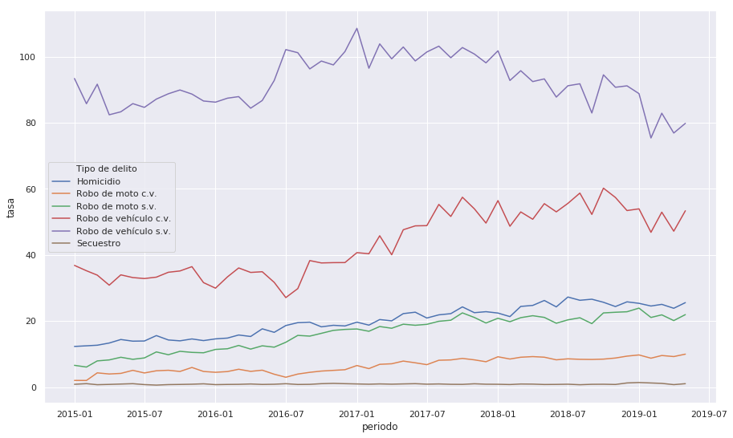

```python
sns.lineplot(x="periodo", y="tasa", hue="Tipo de delito",data=delitos_mexico, ci=None)
```

# Homicidio - Nacional

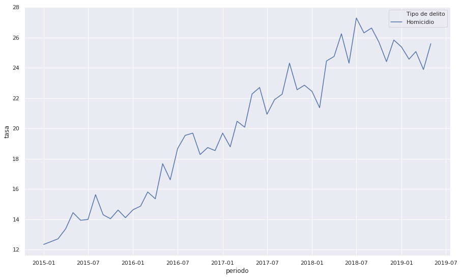

```python
homicidios = delitos_mexico[delitos_mexico['Tipo de delito'] == 'Homicidio']
sns.lineplot(x="periodo", y="tasa", hue="Tipo de delito",data=homicidios, ci=None)
```

## Podemos observar una clara tendencia a la alza.

## Vamos ahora a ver datos de todas las entidades

# Homicidio Doloso - Entidades

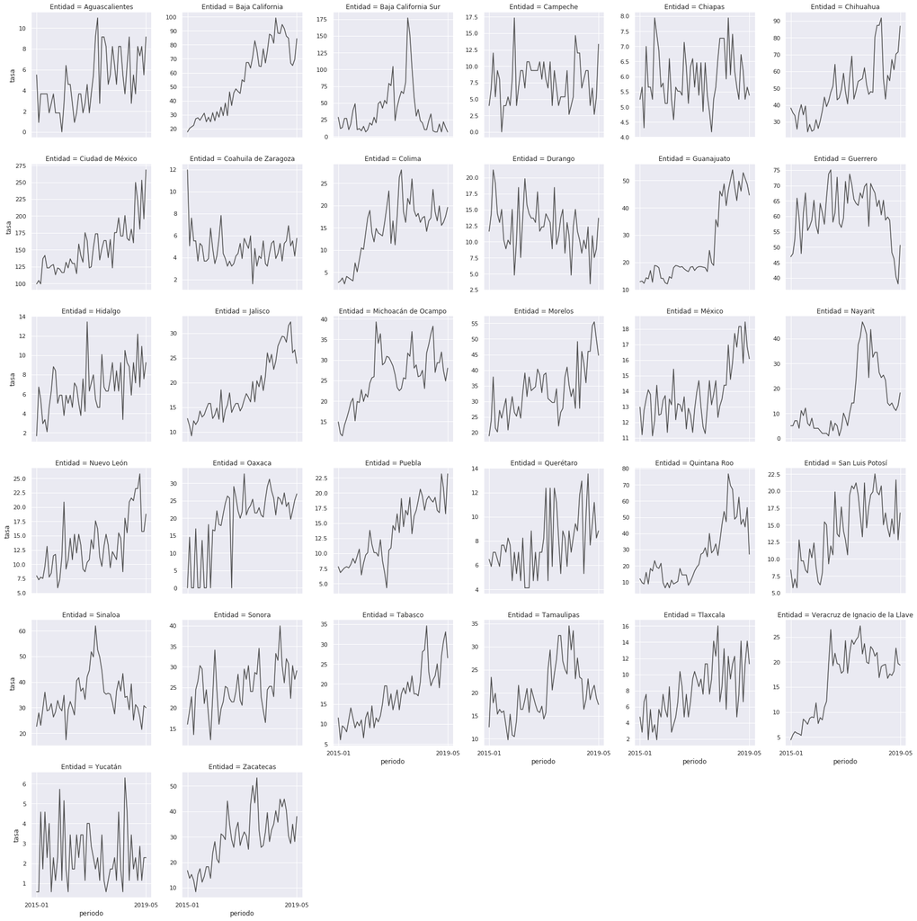

```python
g = sns.FacetGrid(df_agregados[df_agregados['Tipo de delito'] == 'Homicidio'], col="Entidad", col_wrap=6, height=4, sharey=False)
g.map(sns.lineplot, "periodo", "tasa", color=".3", ci=None)
g.set(xticks=['2015-01-01','2019-05-01'])
```

# Robo de vehículo con violencia - Entidades

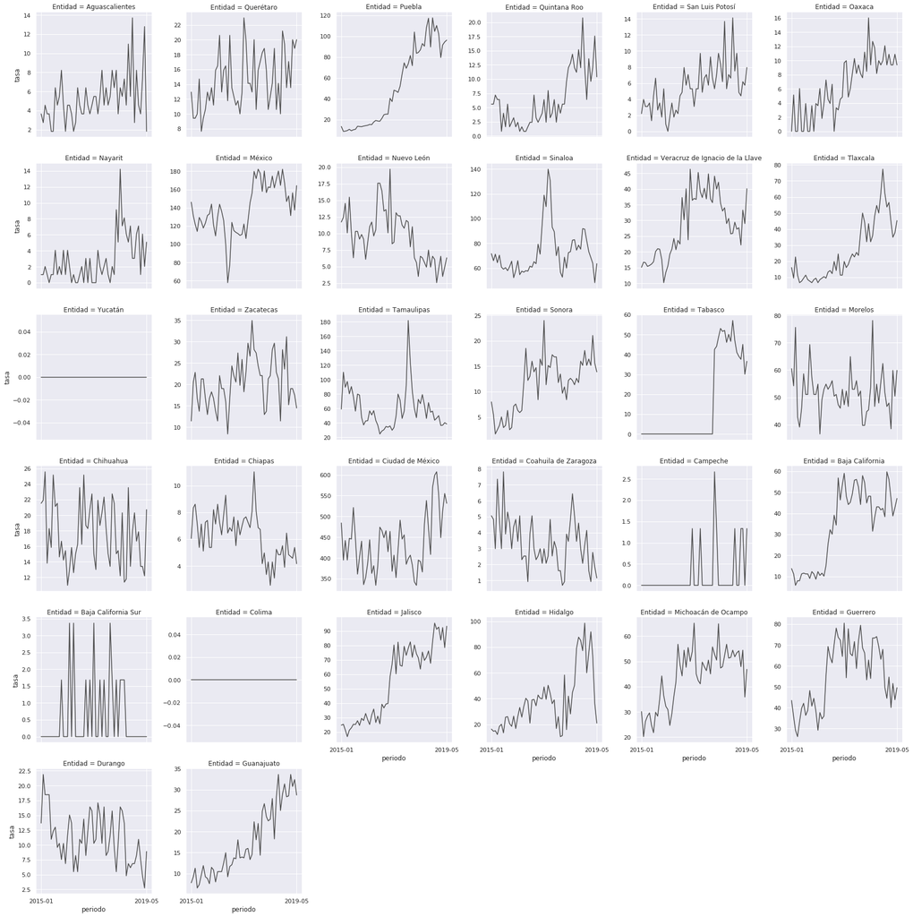

```python
data = df_agregados[df_agregados['Tipo de delito'] == 'Robo de vehículo c.v.'].sort_values('Tipo de delito')
g = sns.FacetGrid(data, col="Entidad", col_wrap=6, height=4, sharey=False)
g.map(sns.lineplot, "periodo", "tasa", color=".3", ci=None)
g.set(xticks=['2015-01-01','2019-05-01'])
```

# Secuestro - Entidades

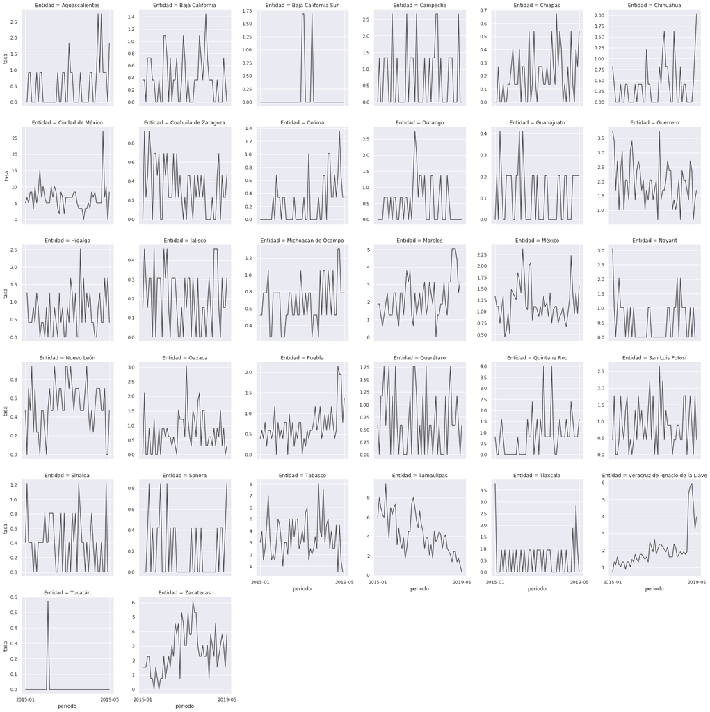

```python
data = df_agregados[df_agregados['Tipo de delito'] == 'Secuestro']
g = sns.FacetGrid(data, col="Entidad", col_wrap=6, height=4, sharey=False)
g.map(sns.lineplot, "periodo", "tasa", color=".3", ci=None)
g.set(xticks=['2015-01-01','2019-05-01'])
```

# CDMX

```python
cdmx = df_agregados[df_agregados['Entidad']=='Ciudad de México']
```

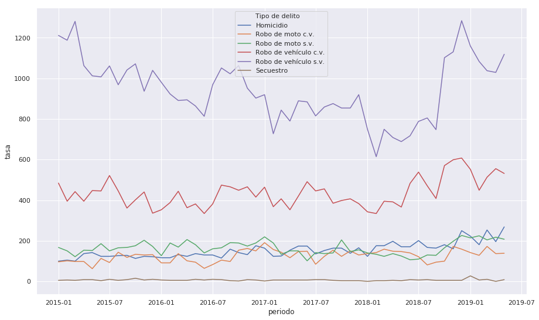

```python
sns.lineplot(x="periodo", y="tasa", hue="Tipo de delito", data=cdmx)
```

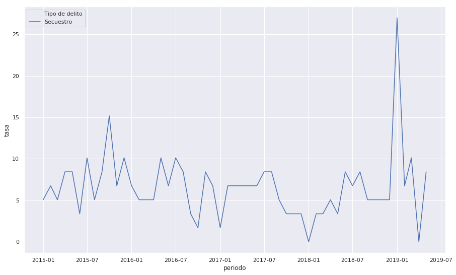

```python
sns.lineplot(x="periodo", y="tasa", hue="Tipo de delito", data=cdmx[cdmx['Tipo de delito']=='Secuestro'] )
```

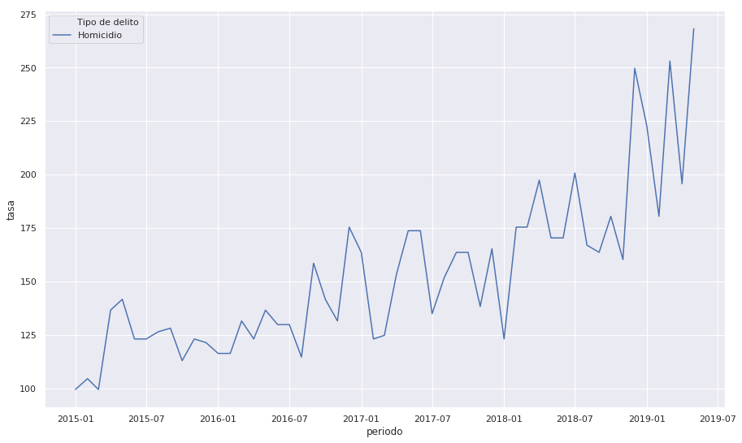

```python
sns.lineplot(x="periodo", y="tasa", hue="Tipo de delito", data=cdmx[cdmx['Tipo de delito']=='Homicidio'] )
```

## Líneas de tendencia

Para ajustar un polinomio a esta gráfica, tenemos que convertir las fechas (eje x) a datos numéricos

```python
df_agregados['fecha_ordinal'] = pd.to_datetime(df_agregados['periodo']).apply(lambda date: date.toordinal())
cdmx = df_agregados[df_agregados['Entidad']=='Ciudad de México']
homicidios_cdmx = cdmx[cdmx['Tipo de delito'] == 'Homicidio']
```

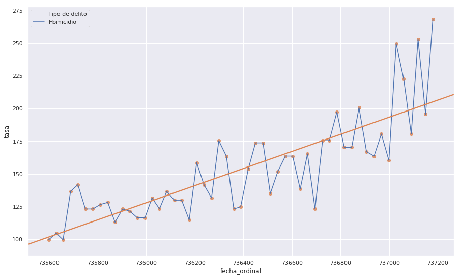

```python
sns.lineplot(x="fecha_ordinal", y="tasa", hue="Tipo de delito",data=homicidios_cdmx, ci=None)
sns.regplot(x="fecha_ordinal", y="tasa", data=homicidios_cdmx, ci=None)
```

#### Pero ahora hay que parsear las etiquetas del eje x

```
Text(0.5,1,'Homicidios CDMX')
```

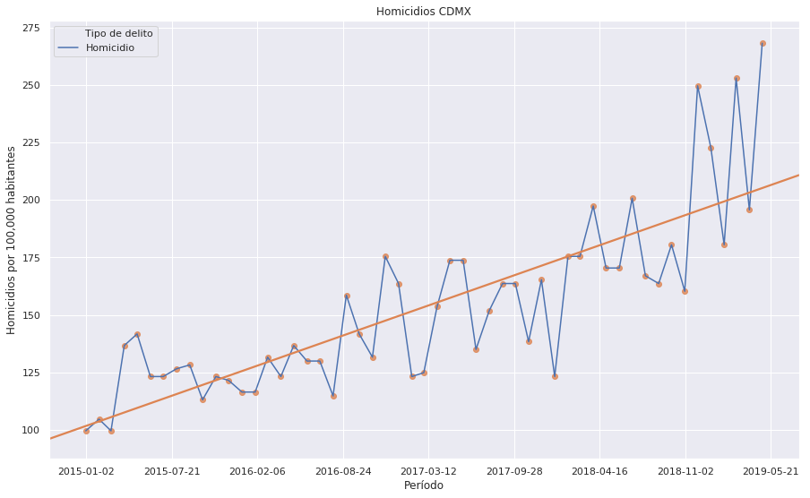

```python
_plt = sns.lineplot(x="fecha_ordinal", y="tasa", hue="Tipo de delito",data=homicidios_cdmx, ci=None)
etiquetas_nuevas = [datetime.date.fromordinal(int(item)) for item in _plt.get_xticks()]
_plt.set_xticklabels(etiquetas_nuevas)
sns.regplot(x="fecha_ordinal", y="tasa", data=homicidios_cdmx, ci=None)
_plot = _plt.set_xlabel('Fecha')
_plt.set(xlabel='Período', ylabel='Homicidios por 100,000 habitantes')
_plt.set_title('Homicidios CDMX')
```

```python
import geopandas as gpd
import matplotlib.pyplot as plt
```

```python
mexico_shp = gpd.read_file('shape_files/national_estatal.shp')
```

```python
df_agregados.head()
```

|  | periodo | Tipo de delito | Entidad | total | Cve_Entidad | Poblacion | tasa | fecha_ordinal |
| --- | --- | --- | --- | --- | --- | --- | --- | --- |
| 0 | 2015-01-01 | Homicidio | Aguascalientes | 6.0 | 1 | 1312544.0 | 5.485530 | 735599 |
| 1 | 2015-01-01 | Robo de moto c.v. | Aguascalientes | 1.0 | 1 | 1312544.0 | 0.914255 | 735599 |
| 2 | 2015-01-01 | Robo de moto s.v. | Aguascalientes | 26.0 | 1 | 1312544.0 | 23.770632 | 735599 |
| 3 | 2015-01-01 | Robo de vehículo c.v. | Aguascalientes | 4.0 | 1 | 1312544.0 | 3.657020 | 735599 |
| 4 | 2015-01-01 | Robo de vehículo s.v. | Aguascalientes | 128.0 | 1 | 1312544.0 | 117.024648 | 735599 |

```python
mx_shp = gpd.GeoDataFrame(mexico_shp[['CVEGEO', 'NOMBRE', 'OID', 'geometry']])
```

```python
mx_shp.shape
```

```
(32, 4)
```

```python
tasa_hom_may_2019 = df_agregados[ (df_agregados['Tipo de delito'] == 'Homicidio') & (df_agregados.periodo.dt.year == 2019) ]
tasa_hom_may_2019 = tasa_hom_may_2019[tasa_hom_may_2019.periodo.dt.month==5]
tasa_hom_may_2019 = tasa_hom_may_2019[['Cve_Entidad', 'tasa']]
tasa_hom_may_2019.head()
```

|  | Cve_Entidad | tasa |
| --- | --- | --- |
| 312 | 1 | 9.142551 |
| 630 | 2 | 84.324406 |
| 948 | 3 | 6.741298 |
| 1266 | 4 | 13.334356 |
| 1584 | 7 | 5.381979 |

```python
mx_shp = mx_shp.merge(tasa_hom_may_2019, left_on="OID", right_on="Cve_Entidad")
```

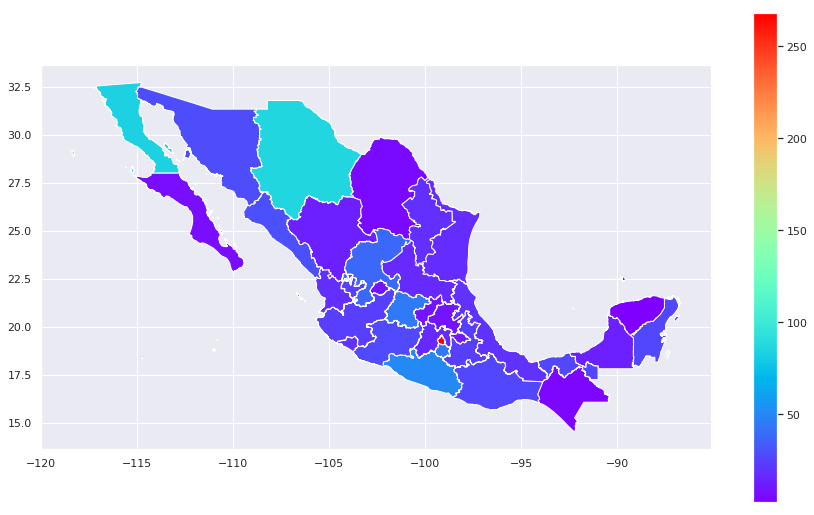

```python
mx_shp.plot(column="tasa", legend=True, cmap="rainbow")
```

## Una gráfica más significativa...

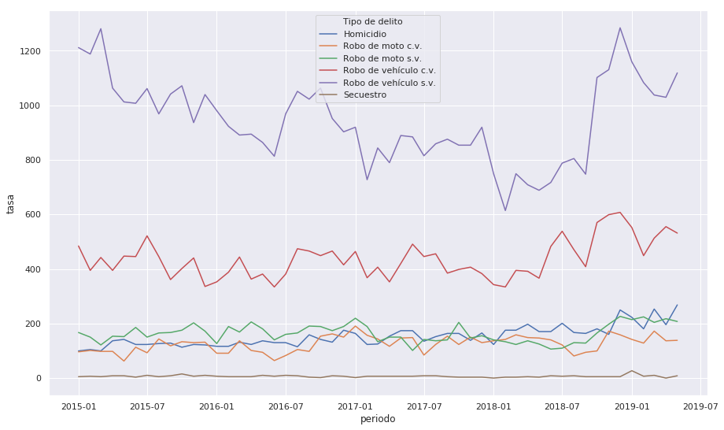

```python
sns.lineplot(x="periodo", y="tasa", hue="Tipo de delito", data=cdmx)
```

```python
cdmx.head()
```

|  | periodo | Tipo de delito | Entidad | total | Cve_Entidad | Poblacion | tasa | fecha_ordinal |
| --- | --- | --- | --- | --- | --- | --- | --- | --- |
| 1908 | 2015-01-01 | Homicidio | Ciudad de México | 59.0 | 9 | 711235.0 | 99.545157 | 735599 |
| 1909 | 2015-01-01 | Robo de moto c.v. | Ciudad de México | 57.0 | 9 | 711235.0 | 96.170745 | 735599 |
| 1910 | 2015-01-01 | Robo de moto s.v. | Ciudad de México | 99.0 | 9 | 711235.0 | 167.033400 | 735599 |
| 1911 | 2015-01-01 | Robo de vehículo c.v. | Ciudad de México | 287.0 | 9 | 711235.0 | 484.228138 | 735599 |
| 1912 | 2015-01-01 | Robo de vehículo s.v. | Ciudad de México | 718.0 | 9 | 711235.0 | 1211.413949 | 735599 |

```python
tasa_base = cdmx[cdmx['periodo'] == '2015-01-1'][['tasa', 'Tipo de delito']]
tasa_base.columns=('tasa_base', 'Tipo de delito')
```

```python
cdmx = cdmx.merge(tasa_base, on ='Tipo de delito')
```

```python
cdmx.tail()
```

|  | periodo | Tipo de delito | Entidad | total | Cve_Entidad | Poblacion | tasa | fecha_ordinal | tasa_base |
| --- | --- | --- | --- | --- | --- | --- | --- | --- | --- |
| 313 | 2019-01-01 | Secuestro | Ciudad de México | 16.0 | 9 | 711235.0 | 26.995297 | 737060 | 5.061618 |
| 314 | 2019-02-01 | Secuestro | Ciudad de México | 4.0 | 9 | 711235.0 | 6.748824 | 737091 | 5.061618 |
| 315 | 2019-03-01 | Secuestro | Ciudad de México | 6.0 | 9 | 711235.0 | 10.123236 | 737119 | 5.061618 |
| 316 | 2019-04-01 | Secuestro | Ciudad de México | 0.0 | 9 | 711235.0 | 0.000000 | 737150 | 5.061618 |
| 317 | 2019-05-01 | Secuestro | Ciudad de México | 5.0 | 9 | 711235.0 | 8.436030 | 737180 | 5.061618 |

[figure not shown]

```python
f, ax = plt.subplots(1, figsize=(16, 12))
ax = sns.lineplot(x="periodo", y=cdmx['tasa']/cdmx['tasa_base'], hue="Tipo de delito", data=cdmx, ax=ax)
ax.set_title('Incidencia Delictiva CDMX Enero 2015 a Mayo 2015')
ax.set(xlabel='Mes', ylabel='Tasa Reescalada')
```

```python
robo_v = cdmx[ (cdmx['Tipo de delito'] != 'Homicidio') & (cdmx['Tipo de delito'] != 'Secuestro')]
tipos = list(robo_v['Tipo de delito'].unique())
```

[figure not shown]

```python
f, ax = plt.subplots(4, figsize=(16, 12))
for ind, ax in enumerate(ax):
    _sub = robo_v[robo_v['Tipo de delito'] == tipos[ind]]
    ax = sns.lineplot(x="periodo", y=_sub['tasa']/_sub['tasa_base'], hue="Tipo de delito", data=_sub, ax=ax)
    sns.regplot(x='fecha_ordinal', y=_sub['tasa']/_sub['tasa_base'], ci=None, data=_sub, ax=ax)
    ax.set_title(tipos[ind] + 'Enero 2015 a Mayo 2015')
    ax.set(xlabel='Mes', ylabel='Tasa Reescalada')
f.subplots_adjust(bottom=-0.8, top=1)
f.savefig('robo_v.png', bbox_inches='tight')
```

```python
homicidios = cdmx[cdmx['Tipo de delito'] == 'Homicidio']
homicidios.head()
```

|  | periodo | Tipo de delito | Entidad | total | Cve_Entidad | Poblacion | tasa | fecha_ordinal | tasa_base |
| --- | --- | --- | --- | --- | --- | --- | --- | --- | --- |
| 0 | 2015-01-01 | Homicidio | Ciudad de México | 59.0 | 9 | 711235.0 | 99.545157 | 735599 | 99.545157 |
| 1 | 2015-02-01 | Homicidio | Ciudad de México | 62.0 | 9 | 711235.0 | 104.606776 | 735630 | 99.545157 |
| 2 | 2015-03-01 | Homicidio | Ciudad de México | 59.0 | 9 | 711235.0 | 99.545157 | 735658 | 99.545157 |
| 3 | 2015-04-01 | Homicidio | Ciudad de México | 81.0 | 9 | 711235.0 | 136.663691 | 735689 | 99.545157 |
| 4 | 2015-05-01 | Homicidio | Ciudad de México | 84.0 | 9 | 711235.0 | 141.725309 | 735719 | 99.545157 |

[figure not shown]

```python
f, ax = plt.subplots(figsize=(16, 3))
sns.lineplot(x="periodo", y=homicidios['tasa']/homicidios['tasa_base'], hue="Tipo de delito", data=homicidios, ax=ax)
sns.regplot(x='fecha_ordinal', y=homicidios['tasa']/homicidios['tasa_base'], ci=None, data=homicidios, ax=ax)
ax.set_title('Homicidios CDMX Enero 2015 a Mayo 2015')
ax.set(xlabel='Mes', ylabel='Tasa Reescalada')
f.subplots_adjust(bottom=-0.8, top=1)
f.savefig('homicidios_cdmx.png', bbox_inches='tight')
```